# Finalized_Code

Author

Samantha Mislinski and Miranda Scalzo

# 1 Introduction

The data for this project comes from Moorea French Polynisea. LTER: Coral Reef: Long-term Population and Community Dynamics: Fishes, ongoing since 2005 ver 62. Environmental Data Initiative.

For this project, we focused on two species, orange spine unicorn fish (*Naso lituratus*) and spotted sharpnose puffer (*Canthigaster solandri*). The orange spine unicorn fish is fished throughout it’s Moorea range. The spotted sharpnose puffer fish is not fished in Moorea. We chose these species to see if there was a difference in the change in their population and biomass due to fishing pressure.

We first plotted the yearly counts and average biomass across the time series for these two species. We noticed that the average counts for the orange spine unicorn decreased throughout time and the biomass increased. The count and biomass did not appear to change for the spotted sharpnose puffer fish. This difference in the two species, may be due to fishing pressure, or more specifically a new regulation on the size. The larger the fish, the more and healthier the offspring. If there was a size limit to leave the larger fish, this pattern of counts decreasing but biomass increasing would make sense. We wanted to understand what would the future population look like for these to species.

We used an ARIMA model to analyze the data and predict what will happen to the fish populations over the next five years. To prep the data, the average counts and biomass was determined for each year. The total area of the study area was calculated and then used to get the densities of the average counts and biomass. The ARIMA model works best on densities, so this is why we did this.

# 2 Libraries

```r
library(tidyverse)
library(here)
library(dplyr)
library(forecast)
```

# 3 Reading in and Cleaning the Data

```r
#creating the home ranges we have 6 sites in square kilometers
site_1 <- 658.94
site_2 <- 2.84
site_3 <- 3.78
site_4 <- 4.26
site_5 <- 8.62
site_6 <- 5.72

total_hr <- sum(site_1, site_2, site_3, site_4, site_5, site_6)
```

```r
#read in the data, filter out the species we need, group by year and location. Mutate to get densities based on the study sites (homerange)

annual_survey <- read_csv(here('Data','MCR_LTER_Annual_Fish_Survey_20230615.csv'))
#for the orange spine unicorn fish

osu_df <- annual_survey |>
  filter(Taxonomy == "Naso lituratus") |>
  group_by(Year) |>  # Grouping by both Year and Site
  summarise(
    Avg_Count = mean(Count, na.rm = TRUE),
    Avg_Biomass = mean(Biomass, na.rm = TRUE)
  ) |>
  mutate(
    count_density = Avg_Count / total_hr,
    biomass_density = Avg_Biomass / total_hr
  )
############# for the spotted puffers #################

ssp_df <- annual_survey |>
  filter(Taxonomy == "Canthigaster solandri") |>
  group_by(Year) |>
  summarise(
    Avg_Count = mean(Count, na.rm = TRUE),
    Avg_Biomass = mean(Biomass, na.rm = TRUE)
  ) |>
  mutate(
    count_density = Avg_Count / total_hr,
    biomass_density = Avg_Biomass / total_hr
  )

osu_count_df <- osu_df |> select(Year, count_density)
osu_biomass_df  <- osu_df |> select(Year, biomass_density)

ssp_count_df <- ssp_df |> select(Year, count_density)
ssp_biomass_df  <- ssp_df |> select(Year, biomass_density)

#turn data into a time series file
##when creating a time series object, need to make sure to specify the correct start year and frequency
osu_count_ts<-ts(osu_count_df$count_density, start = min(osu_count_df$Year), frequency = 1)
osu_biomass_ts<-ts(osu_biomass_df$biomass_density, start = min(osu_biomass_df$Year), frequency = 1)

ssp_count_ts<-ts(ssp_count_df$count_density, start = min(ssp_count_df$Year), frequency = 1)
ssp_biomass_ts<-ts(ssp_biomass_df$biomass_density, start = min(ssp_biomass_df$Year), frequency = 1)
```

# 4 Running the AREMA Models

## 4.1 For the orange spine unicorn fish count data

```r
osu_count_arima <- auto.arima(osu_count_ts) #Returns best ARIMA model according to either AIC, AICc or BIC value. The function conducts a
# search over possible model within the order constraints provided.##too out BIC just to see if it would choose same ARIMA model which it did
summary(osu_count_arima)
```

```
Series: osu_count_ts
ARIMA(0,1,0)

sigma^2 = 9.746e-07:  log likelihood = 88.03
AIC=-174.05   AICc=-173.77   BIC=-173.28

Training set error measures:
                        ME         RMSE          MAE       MPE    MAPE
Training set -3.687767e-05 0.0009577514 0.0006582585 -4.147424 17.6701
                  MASE       ACF1
Training set 0.9414077 -0.1230024
```

```r
##random walk model which the auto arima is choosing may not actually be the best model because it's just assuming that the best forecast for the future is the most recent observed value (hence the flat forecast line)
##trying an Arima (1,1,1) model which uses past trends instead of just carrying the last observed value forward

osu_count_arima_alt <- Arima(osu_count_ts, order = c(1,1,1))
summary(osu_count_arima_alt)
```

```
Series: osu_count_ts
ARIMA(1,1,1)

Coefficients:
         ar1      ma1
      0.7378  -1.0000
s.e.  0.2141   0.2498

sigma^2 = 9.554e-07:  log likelihood = 88.64
AIC=-171.28   AICc=-169.28   BIC=-168.96

Training set error measures:
                        ME         RMSE          MAE       MPE     MAPE
Training set -5.052625e-05 0.0008870277 0.0006404663 -5.732051 18.05293
                  MASE        ACF1
Training set 0.9159623 -0.01078077
```

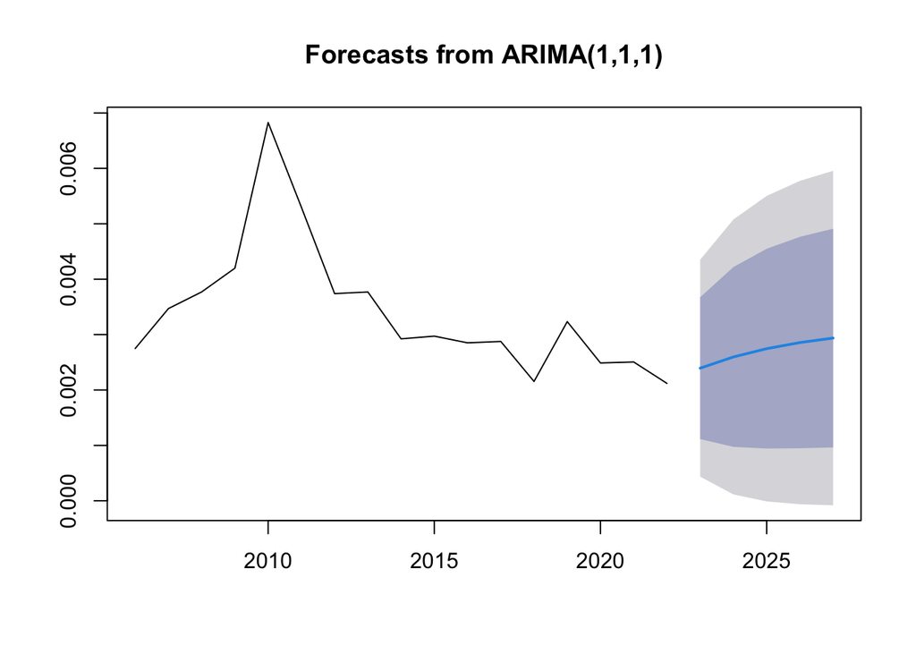

This graph shows the forcasted population count density for orange sipine unicorn fish using ARIMA.

```r
osu_count_forecasted_values_alt <- forecast::forecast(osu_count_arima_alt, h = 5)
plot(osu_count_forecasted_values_alt)
```

```r
##compare model performance to check
AIC(osu_count_arima_alt)  # ARIMA(1,1,1)
```

```
[1] -171.2802
```

```r
AIC(osu_count_arima)  # ARIMA(0,1,0)
```

```
[1] -174.0535
```

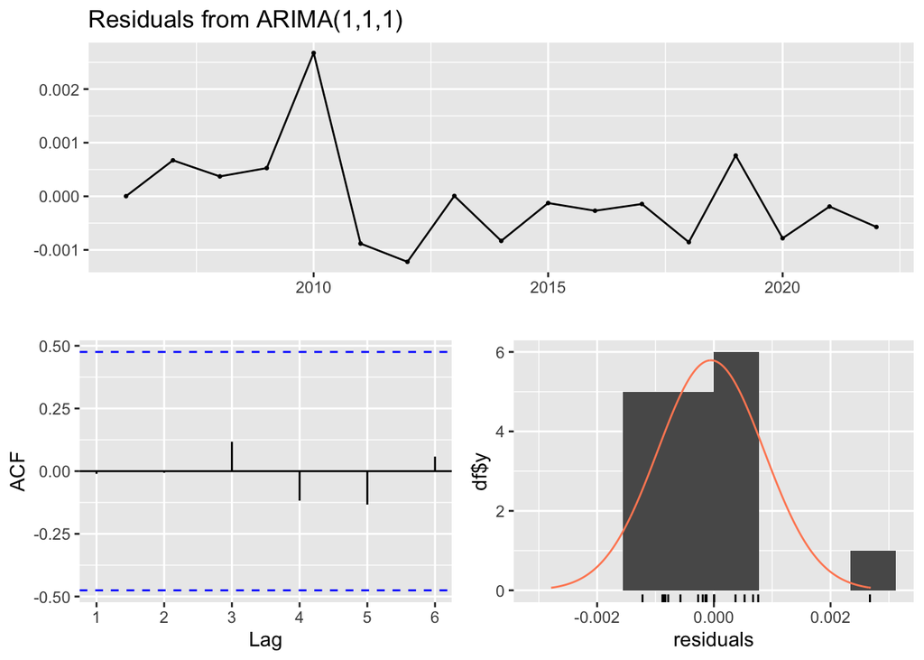

```
    Ljung-Box test

data:  Residuals from ARIMA(1,1,1)
Q* = 1.1438, df = 3, p-value = 0.7665

Model df: 2.   Total lags used: 5
```

```r
checkresiduals(osu_count_arima_alt)
```

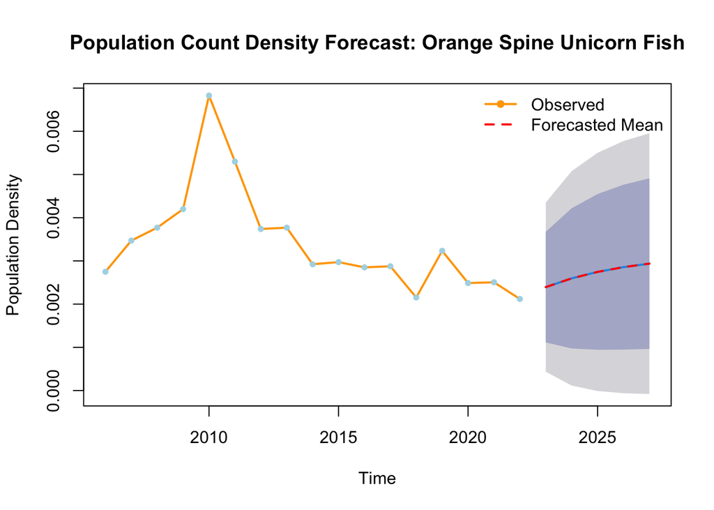

This graph shows the forcasted population count density for orange sipine unicorn fish using ARIMA.

```r
##Residuals look reasonable: No strong autocorrelation, meaning it's capturing key patterns.
##use this arima model instead

##plot foreecast with observed data for OSU count
plot(osu_count_forecasted_values_alt,
     main= "Population Count Density Forecast: Orange Spine Unicorn Fish",
     xlab= "Time",
     ylab= "Population Density",
     col= "orange",
     lwd= 2,
     include=length(osu_count_ts))
##add data points

points(time(osu_count_ts), osu_count_ts, col = "lightblue", pch = 16, cex = 0.8)

# Manually add forecasted values as a separate line
lines(time(osu_count_ts)[length(osu_count_ts)] + 1:5,
      osu_count_forecasted_values_alt$mean,
      col = "red", lwd = 2, lty = 2)

##add a legend
legend("topright",
       legend = c("Observed", "Forecasted Mean"),
       col = c("orange", "red"),
       lwd = c(2, 2),
       pch = c(16, NA),
       lty = c(1, 2),
       bty = "n")
```

```r
# Extract the standard deviation of forecasted count values
forecast_sd_count <- osu_count_forecasted_values_alt$residuals

# Print the standard deviation
sd_forecast_count <- sd(forecast_sd_count, na.rm = TRUE)  # Remove NAs to avoid errors
print(sd_forecast_count)
```

```
[1] 0.0009128427
```

## 4.2 For the orange spine unicorn fish biomass data

```r
###New code for ARIMA model (1,1,1)
## run the arima model and forecast out 5 years
osu_biomass_arima_alt <- Arima(osu_biomass_ts, order = c(1,1,1))
summary(osu_biomass_arima_alt)
```

```
Series: osu_biomass_ts
ARIMA(1,1,1)

Coefficients:
          ar1      ma1
      -0.4341  -0.0057
s.e.   1.0599   1.1498

sigma^2 = 0.00509:  log likelihood = 20.5
AIC=-35   AICc=-33   BIC=-32.69

Training set error measures:
                     ME       RMSE       MAE      MPE     MAPE      MASE
Training set 0.01924319 0.06474645 0.0482352 2.921795 22.11193 0.8831105
                    ACF1
Training set -0.04000387
```

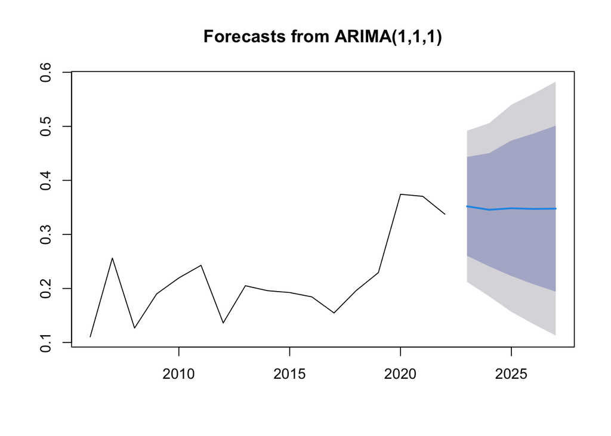

This graph shows the forcasted population biomass densitiy for orang sipine unicorn fish using ARIMA.

```r
osu_biomass_forecasted_values_alt <- forecast::forecast(osu_biomass_arima_alt, h = 5)
plot(osu_biomass_forecasted_values_alt)
```

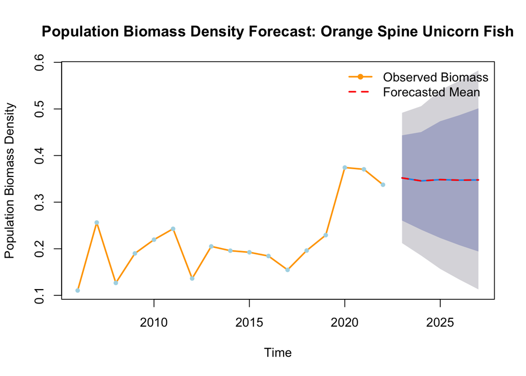

This graph shows the forcasted population biomass densitiy for orang sipine unicorn fish using ARIMA.

```r
##plot foreecast with observed data for OSU biomass
plot(osu_biomass_forecasted_values_alt,
     main= "Population Biomass Density Forecast: Orange Spine Unicorn Fish",
     xlab= "Time",
     ylab= "Population Biomass Density",
     col= "orange",
     lwd= 2,
     include=length(osu_biomass_ts))

##add observed biomass data points to graph

points(time(osu_biomass_ts), osu_biomass_ts, col = "lightblue", pch = 16, cex = 0.8)

# Manually add forecasted values for biomass as a separate line
lines(time(osu_biomass_ts)[length(osu_biomass_ts)] + 1:5,
      osu_biomass_forecasted_values_alt$mean,
      col = "red", lwd = 2, lty = 2)

##add a legend
legend("topright",
       legend = c("Observed Biomass", "Forecasted Mean"),
       col = c("orange", "red"),
       lwd = c(2, 2),
       pch = c(16, NA),
       lty = c(1, 2),
       bty = "n")
```

```r
# Extract the standard deviation of forecasted biomass values
forecast_sd_biomass <- osu_biomass_forecasted_values_alt$residuals

# Print the standard deviation
sd_forecast_biomass <- sd(forecast_sd_biomass, na.rm = TRUE)  # Remove NAs to avoid errors
print(sd_forecast_biomass)
```

```
[1] 0.06372334
```

## 4.3 For the Spotted Puffer Fish Count Density

```r
##Code for ARIMA model (1,1,1) for modeling spotted puffer fish count
#### run the arima model and forecast out 5 years
ssp_count_arima_alt <- Arima(ssp_count_ts, order = c(1,1,1))
summary(ssp_count_arima_alt)
```

```
Series: ssp_count_ts
ARIMA(1,1,1)

Coefficients:
         ar1      ma1
      0.0503  -0.9999
s.e.  0.2529   0.3991

sigma^2 = 7.249e-08:  log likelihood = 108.52
AIC=-211.03   AICc=-209.03   BIC=-208.71

Training set error measures:
                        ME         RMSE          MAE       MPE    MAPE
Training set -1.325252e-05 0.0002443256 0.0001849993 -1.917975 8.84573
                  MASE        ACF1
Training set 0.6080764 -0.02949747
```

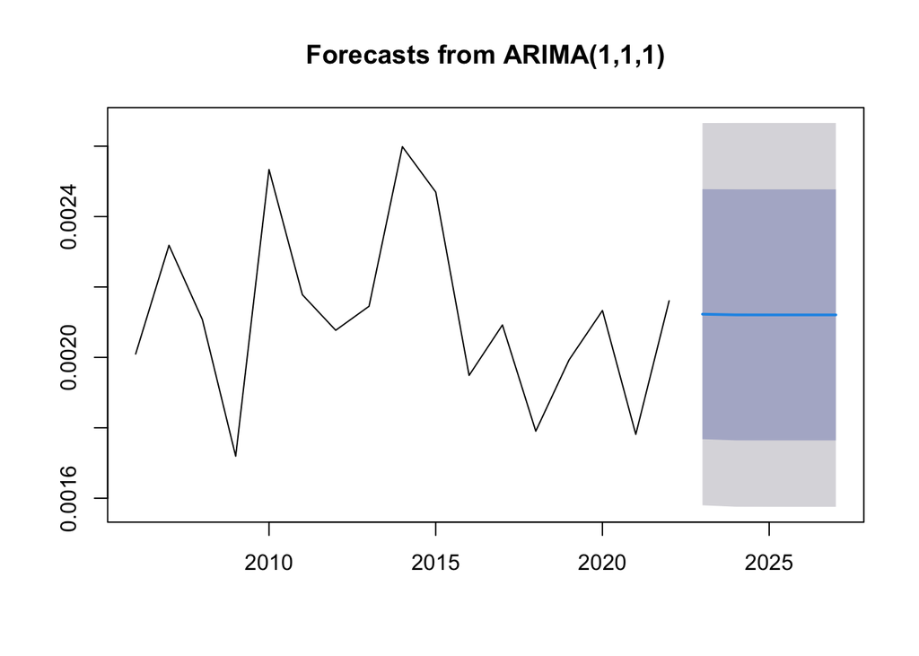

This graph shows the forcasted population count densitiy for spotted puffers using ARIMA.

```r
ssp_count_forecasted_values_alt <- forecast::forecast(ssp_count_arima_alt, h = 5)
plot(ssp_count_forecasted_values_alt)
```

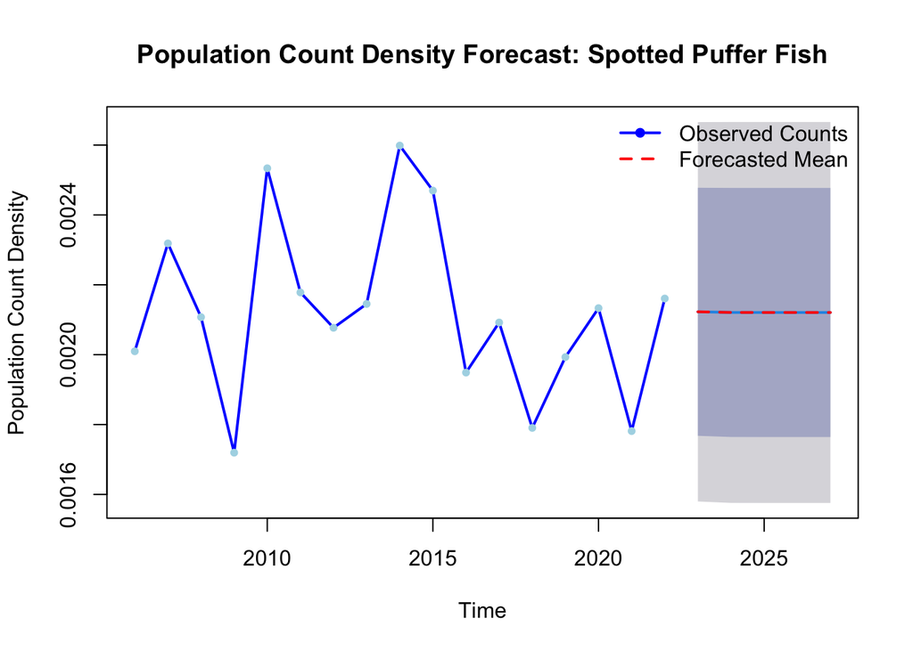

This graph shows the forcasted population count densitiy for spotted puffers using ARIMA.

```r
##plot foreecast with observed data for SSP counts
plot(ssp_count_forecasted_values_alt,
     main= "Population Count Density Forecast: Spotted Puffer Fish",
     xlab= "Time",
     ylab= "Population Count Density",
     col= "blue",
     lwd= 2,
     include=length(ssp_count_ts))

##add observed count data points to graph

points(time(ssp_count_ts), ssp_count_ts, col = "lightblue", pch = 16, cex = 0.8)

# Manually add forecasted values for count as a separate line
lines(time(ssp_count_ts)[length(ssp_count_ts)] + 1:5,
      ssp_count_forecasted_values_alt$mean,
      col = "red", lwd = 2, lty = 2)

##add a legend
legend("topright",
       legend = c("Observed Counts", "Forecasted Mean"),
       col = c("blue", "red"),
       lwd = c(2, 2),
       pch = c(16, NA),
       lty = c(1, 2),
       bty = "n")
```

```r
# Extract the standard deviation of forecasted count values
ssp_forecast_sd_count <- ssp_count_forecasted_values_alt$residuals

# Print the standard deviation
ssp_sd_forecast_count <- sd(ssp_forecast_sd_count, na.rm = TRUE)  # Remove NAs to avoid errors
print(ssp_sd_forecast_count)
```

```
[1] 0.0002514743
```